# Territorios sin cartografiar — análisis textual del corpus

Fase exploratoria del TIM: frecuencias, TF-IDF, Zipf, Heaps y una huella estilométrica

Eugenio Torres Flawiá

2026-11-11

## Preparación: pipeline sobre el corpus propio

Este script adapta el pipeline de la ejercitación de la Unidad 2 al corpus de la muestra del proyecto: cinco ficciones argentinas contemporáneas (Enríquez, Romero, Ferrari). Dos decisiones metodológicas lo distinguen de la guía:

1. **Stopwords**: se usa exclusivamente la lista curada del proyecto (`stopwords_UmbralWeird_v2_completa.txt`, 302 términos), la misma aplicada en Voyant Tools. Un filtro idéntico en ambas herramientas hace comparables sus salidas, que es lo que la consigna pide contrastar. La lista preserva deliberadamente los indefinidos (*algo*, *nada*, *nadie*, *alguien*) y la deixis temporal, relevantes para la hipótesis de lectura, e incorpora el voseo rioplatense.
2. **Limpieza**: se eliminan dígitos y tokens residuales de un solo carácter, pero **no** se aplica el filtro `nchar > 3` de la guía, que eliminaría monosílabos y bisílabos plenos (*luz*, *voz*, *casa* queda, *río*, *mar*) y rompería la comparabilidad con Voyant, que no filtra por longitud.

Los textos completos se leen de `data/raw_full/`, carpeta local excluida del versionado público por derechos de autor (ver `data/raw/NOTA_METODOLOGICA.md`). Este documento debe tejerse desde `scripts/`, de modo que las rutas relativas `../` resuelvan dentro del repositorio.

```r
library(tidyverse)
library(tidytext)

RAW_FULL <- "../data/raw_full"
CLEAN    <- "../data/clean"
MEDIA    <- "../media"

if (!dir.exists(RAW_FULL)) {
  stop("No se encuentra ../data/raw_full/. Esta carpeta contiene los textos ",
       "completos del corpus y queda fuera del repositorio público por ",
       "derechos de autor (ver data/raw/NOTA_METODOLOGICA.md). ",
       "Reponerla localmente antes de tejer.")
}

archivos <- list.files(path = RAW_FULL, pattern = "_limpio\\.txt$")
length(archivos)
```

```
## [1] 5
```

```r
# Etiquetas legibles y autor, derivados del nombre de archivo
etiquetar <- function(archivo) {
  case_when(
    str_detect(archivo, "La_casa_de_Adela")      ~ "Enríquez · Adela",
    str_detect(archivo, "El_patio_del_vecino")   ~ "Enríquez · Patio",
    str_detect(archivo, "El_conserje")           ~ "Romero · Conserje",
    str_detect(archivo, "La_habitacion")         ~ "Romero · Habitación",
    str_detect(archivo, "Territorios")           ~ "Ferrari · Territorios",
    TRUE ~ str_remove(archivo, "_limpio\\.txt$")
  )
}

mensajes <- tibble(textos_archivo = character(),
                   parrafo = numeric(),
                   texto = character())

for (i in seq_along(archivos)) {
  corpus_total <- read_lines(file.path(RAW_FULL, archivos[i]))
  temporal <- tibble(textos_archivo = etiquetar(archivos[i]),
                     parrafo = seq_along(corpus_total),
                     texto = corpus_total)
  mensajes <- bind_rows(mensajes, temporal)
}

mensajes <- mensajes %>%
  mutate(autor = word(textos_archivo, 1))

# Tokenización
mensajes_palabras <- mensajes %>%
  unnest_tokens(palabra, texto)

# Stopwords: lista curada del proyecto (la misma usada en Voyant)
stopwords_uw <- tibble(
  palabra = read_lines(file.path(CLEAN, "stopwords_UmbralWeird_v2_completa.txt"))
) %>%
  filter(palabra != "")

mensajes_sin_vacias <- mensajes_palabras %>%
  anti_join(stopwords_uw, by = "palabra")

# Limpieza: dígitos y residuos de un carácter (sin filtro nchar > 3; ver nota)
limpiar <- function(tabla) {
  tabla %>%
    mutate(palabra = str_remove_all(palabra, "\\d+")) %>%
    filter(nchar(palabra) > 1, palabra != "", palabra != ".", palabra != "n°")
}

mensajes_pal_limpio <- limpiar(mensajes_palabras)   # con vacías
mensajes_limpio     <- limpiar(mensajes_sin_vacias) # sin vacías

# Tabla de control: comparar estas cifras con las del reporte de Voyant
tabla_control <- mensajes_pal_limpio %>%
  group_by(textos_archivo) %>%
  summarize(tokens = n(), vocabulario = n_distinct(palabra)) %>%
  left_join(
    mensajes_limpio %>%
      group_by(textos_archivo) %>%
      summarize(tokens_sin_vacias = n()),
    by = "textos_archivo") %>%
  arrange(desc(tokens))

knitr::kable(tabla_control,
             caption = "Control del corpus: tokens y vocabulario por obra (contrastar con Voyant)")
```

Control del corpus: tokens y vocabulario por obra (contrastar con Voyant)

| textos_archivo | tokens | vocabulario | tokens_sin_vacias |
| --- | --- | --- | --- |
| Romero · Conserje | 32833 | 5121 | 15042 |
| Ferrari · Territorios | 28688 | 6538 | 14366 |
| Romero · Habitación | 11448 | 2220 | 5043 |
| Enríquez · Patio | 6696 | 1889 | 3173 |
| Enríquez · Adela | 3953 | 1267 | 1946 |

El contraste sistemático de estas cifras con las del reporte de Voyant (tokenización, tratamiento de guiones y apóstrofos, efecto de la misma lista de stopwords en ambas herramientas) se desarrolla en la memoria del trabajo (Dimensión textual).

## 1. Frecuencias sin palabras vacías: el léxico del corpus

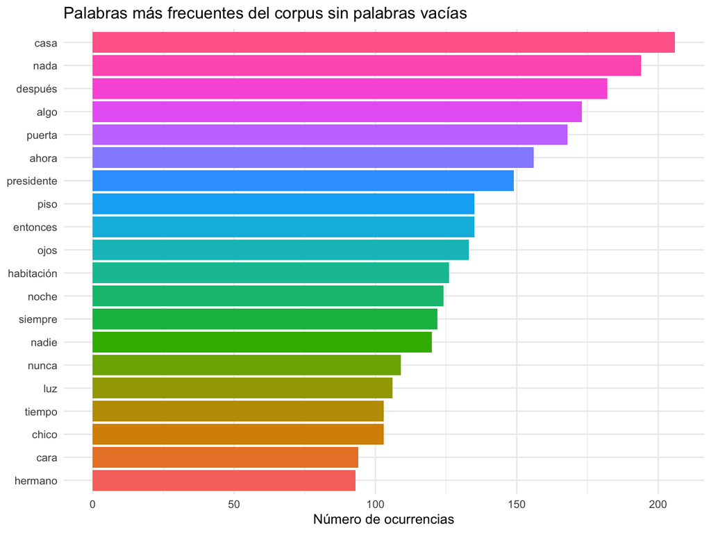

```r
g1 <- mensajes_limpio %>%
  count(palabra, sort = TRUE) %>%
  slice_max(n, n = 20) %>%
  mutate(palabra = reorder(palabra, n)) %>%
  ggplot(aes(x = palabra, y = n, fill = palabra)) +
  geom_col(show.legend = FALSE) +
  coord_flip() +
  theme_minimal() +
  labs(title = "Palabras más frecuentes del corpus sin palabras vacías",
       x = NULL, y = "Número de ocurrencias")
g1
```

```r
ggsave(file.path(MEDIA, "r_frecuencias_corpus.png"), g1,
       width = 8, height = 6, dpi = 150)
```

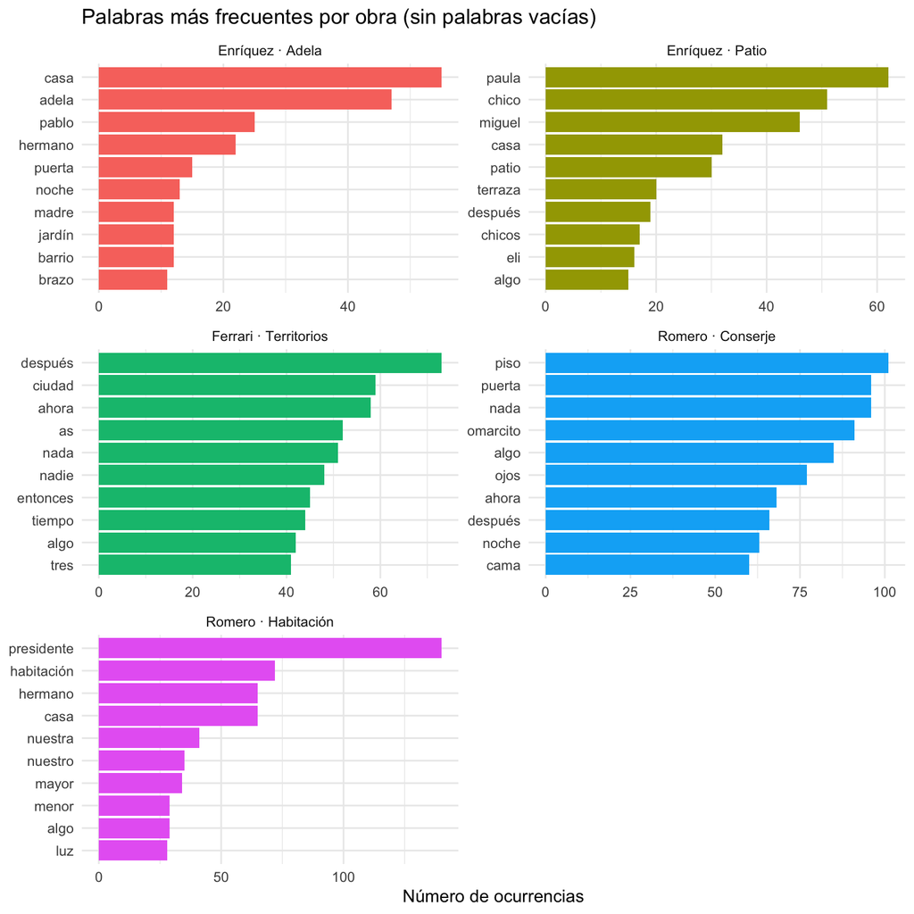

```r
g2 <- mensajes_limpio %>%
  count(textos_archivo, palabra, sort = TRUE) %>%
  group_by(textos_archivo) %>%
  slice_max(n, n = 10, with_ties = FALSE) %>%
  ungroup() %>%
  ggplot(aes(n, reorder_within(palabra, n, textos_archivo),
             fill = textos_archivo)) +
  geom_col(show.legend = FALSE) +
  facet_wrap(~ textos_archivo, scales = "free", ncol = 2) +
  scale_y_reordered() +
  theme_minimal() +
  labs(title = "Palabras más frecuentes por obra (sin palabras vacías)",
       x = "Número de ocurrencias", y = NULL)
g2
```

```r
ggsave(file.path(MEDIA, "r_frecuencias_por_obra.png"), g2,
       width = 9, height = 8, dpi = 150)
```

**Interpretación.** Mi pregunta de investigación es qué les ocurre a las formas reconocibles cuando siguen funcionando después de perder su capacidad de orientarnos; desde ahí leo esta distribución: la casa conserva las paredes, pero el plano ya no garantiza una salida. La primera posición de *casa* y la segunda de *nada* permiten interrogar la convivencia entre insistencia espacial e indeterminación — una entrada estadística a mi concepto de **umbral**: el espacio sigue siendo reconocible mientras su capacidad de garantizar continuidad queda bajo sospecha. *Puerta*, *piso* y *habitación* refuerzan la presencia del ámbito doméstico; *algo*, *nadie* y *nada* —los indefinidos que la lista de stopwords preservó deliberadamente— introducen grados distintos de indeterminación; y la frecuencia de *ojos*, *luz*, *noche* y *cara* abre una línea sobre las condiciones de visibilidad: quién puede ver, qué alcanza a distinguir, qué permanece incierto. Para sostener esta lectura necesito revisar las concordancias: qué niegan esos *nada*, qué anuncian esos *algo* y a quién sustraen esos *nadie*.

## 2. TF-IDF por obra: lo distintivo de cada territorio narrativo

Cada obra se trata como documento; `bind_tf_idf()` destaca lo que cada texto dice y los demás no.

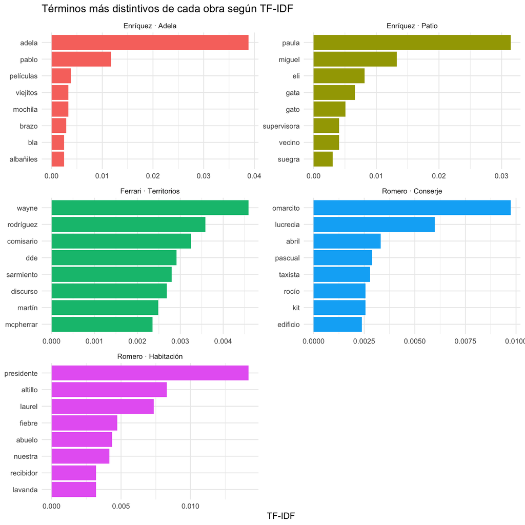

```r
frecuencia_texto <- mensajes_limpio %>%
  count(textos_archivo, palabra, sort = TRUE) %>%
  bind_tf_idf(palabra, textos_archivo, n)

g3 <- frecuencia_texto %>%
  group_by(textos_archivo) %>%
  slice_max(tf_idf, n = 8, with_ties = FALSE) %>%
  ungroup() %>%
  ggplot(aes(tf_idf,
             reorder_within(palabra, tf_idf, textos_archivo),
             fill = textos_archivo)) +
  geom_col(show.legend = FALSE) +
  facet_wrap(~ textos_archivo, scales = "free", ncol = 2) +
  scale_y_reordered() +
  theme_minimal() +
  labs(title = "Términos más distintivos de cada obra según TF-IDF",
       x = "TF-IDF", y = NULL)
g3
```

```r
ggsave(file.path(MEDIA, "r_tfidf_por_obra.png"), g3,
       width = 9, height = 9, dpi = 150)
```

**Interpretación.** El vocabulario distintivo de *Habitación* orienta la lectura hacia la arquitectura como procedimiento: *altillo*, *recibidor* — los recintos y recorridos que distribuyen espera, autoridad y acceso, hasta volver la organización doméstica un campo de acción de la anomalía. En *Adela*, *películas*, *mochila*, *brazo* y *viejitos* proponen otras entradas —consumos culturales, objetos cotidianos, corporalidad—, pistas para volver al texto antes que temas definidos por sí mismas. La aparición de *dde* entre los términos distintivos de Ferrari introduce un límite decisivo: la singularidad estadística también puede proceder del deterioro del archivo. El procedimiento identifica formas infrecuentes en el conjunto sin distinguir su origen narrativo o técnico; por eso el TF-IDF sirve, además, para auditar la digitalización — condición que afecta la interpretación y queda registrada como tal. El cálculo identifica particularidades léxicas; los pasajes deben mostrar cómo trabaja esa distribución sobre personajes y lectores.

## 3. Ley de Zipf: con y sin palabras vacías

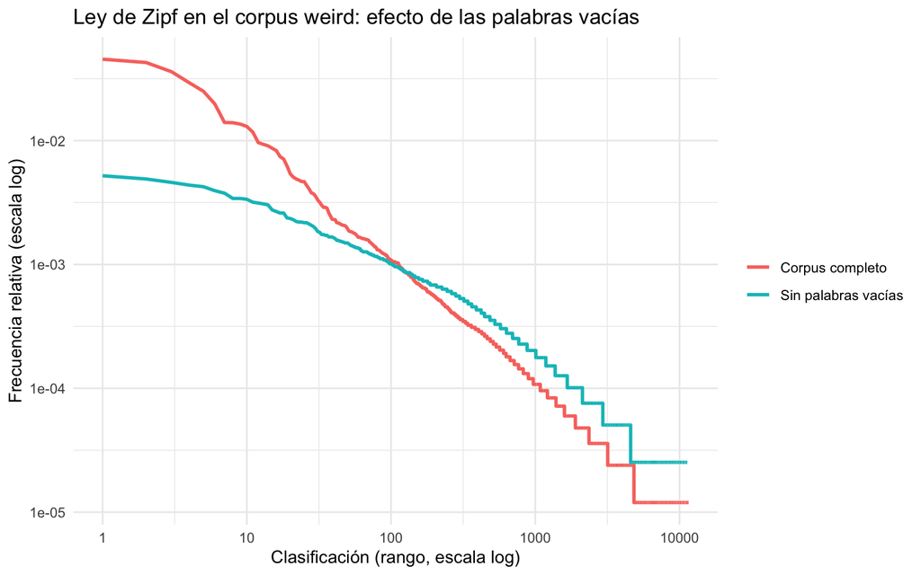

```r
frec_completo <- mensajes_pal_limpio %>%
  count(palabra, sort = TRUE) %>%
  mutate(relativa = n / sum(n),
         Clasificacion = row_number(),
         corpus = "Corpus completo")

frec_sin_vacias <- mensajes_limpio %>%
  count(palabra, sort = TRUE) %>%
  mutate(relativa = n / sum(n),
         Clasificacion = row_number(),
         corpus = "Sin palabras vacías")

g4 <- bind_rows(frec_completo, frec_sin_vacias) %>%
  ggplot(aes(Clasificacion, relativa, color = corpus)) +
  geom_line(linewidth = 1) +
  scale_x_log10() +
  scale_y_log10() +
  theme_minimal() +
  labs(title = "Ley de Zipf en el corpus weird: efecto de las palabras vacías",
       x = "Clasificación (rango, escala log)",
       y = "Frecuencia relativa (escala log)",
       color = NULL)
g4
```

```r
ggsave(file.path(MEDIA, "r_zipf.png"), g4, width = 8, height = 5, dpi = 150)

pendiente <- function(tabla, lo = 10, hi = 1000) {
  datos <- filter(tabla, Clasificacion >= lo, Clasificacion <= hi)
  coef(lm(log10(relativa) ~ log10(Clasificacion), data = datos))[2]
}
pend_completo   <- pendiente(frec_completo)
pend_sin_vacias <- pendiente(frec_sin_vacias)
round(c(corpus_completo = pend_completo, sin_vacias = pend_sin_vacias), 3)
```

```
## corpus_completo.log10(Clasificacion)      sin_vacias.log10(Clasificacion)
##                               -0.978                               -0.676
```

**Interpretación.** La pendiente de −0,978 del corpus completo describe una regularidad cercana al patrón esperado: pocas palabras concentran muchas apariciones y una gran cantidad de formas aparece con baja frecuencia. Al retirar las vacías, la pendiente pasa a −0,676: el preprocesamiento modifica la distribución que se analiza. La coincidencia con el corpus de cronistas de la ejercitación debe presentarse como eso — una coincidencia entre los casos estudiados, no una invariancia general, que exigiría ajustes comparables y una selección mayor de textos. Mi concepto de **entropía narrativa** exige, además, otra observación que este cálculo no provee: cómo una misma superficie admite versiones incompatibles sin permitir que alguna se imponga definitivamente. Mantengo esa diferencia de escala para precisar qué aporta el cálculo y dónde comienza la lectura conceptual.

## 4. Ley de Heaps por obra

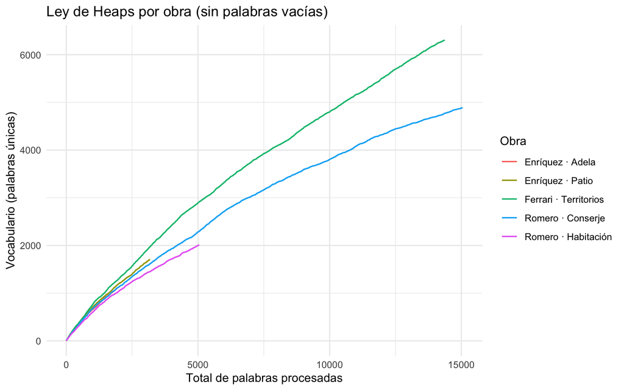

```r
crecimiento_sin_vacias <- mensajes_limpio %>%
  group_by(textos_archivo) %>%
  mutate(total_palabras = row_number(),
         vocabulario = cumsum(!duplicated(palabra))) %>%
  ungroup()

g5 <- ggplot(crecimiento_sin_vacias,
             aes(total_palabras, vocabulario, color = textos_archivo)) +
  geom_line(linewidth = 0.6) +
  theme_minimal() +
  labs(title = "Ley de Heaps por obra (sin palabras vacías)",
       x = "Total de palabras procesadas",
       y = "Vocabulario (palabras únicas)",
       color = "Obra")
g5
```

```r
ggsave(file.path(MEDIA, "r_heaps.png"), g5, width = 8, height = 5, dpi = 150)

tabla_heaps <- crecimiento_sin_vacias %>%
  group_by(textos_archivo) %>%
  summarize(N = max(total_palabras),
            Vocabulario = max(vocabulario),
            beta = round(coef(lm(log10(vocabulario) ~ log10(total_palabras)))[2], 3)) %>%
  arrange(desc(beta))

knitr::kable(tabla_heaps,
             caption = "Ley de Heaps: tamaño, vocabulario y exponente β por obra")
```

Ley de Heaps: tamaño, vocabulario y exponente β por obra

| textos_archivo | N | Vocabulario | beta |
| --- | --- | --- | --- |
| Enríquez · Adela | 1946 | 1112 | 0.867 |
| Enríquez · Patio | 3173 | 1710 | 0.845 |
| Ferrari · Territorios | 14366 | 6305 | 0.829 |
| Romero · Habitación | 5043 | 2013 | 0.821 |
| Romero · Conserje | 15042 | 4889 | 0.786 |

**Interpretación.** Los valores de β permiten comparar el crecimiento del vocabulario, pero las extensiones desiguales obligan a la prudencia que advierten Sano *et al.* (2012): los exponentes se estiman sobre recorridos de distinta longitud. La comparación relevante es Ferrari–Conserje, por sus tamaños próximos tras el filtrado: Ferrari incorpora más formas distintas y muestra un crecimiento estimado mayor, compatible con una diversidad léxica superior — aunque el daño de OCR ofrece una explicación alternativa: cada variante defectuosa puede contabilizarse como palabra nueva. La incertidumbre es, en sí misma, un resultado metodológico: impide atribuir toda diferencia al estilo y señala una comprobación concreta — revisar las formas de baja frecuencia y repetir la comparación sobre segmentos de igual longitud con criterios de limpieza comunes. Antes de interpretar esa diferencia como rasgo de escritura, necesito distinguir cuánto corresponde al texto y cuánto a su digitalización.

## 5. Huella estilométrica: Delta de Burrows con dos pares de autor

El corpus contiene **dos obras de Enríquez y dos de Romero**: dos oportunidades de verificar si las palabras funcionales recuperan la mano del autor, como en Mosteller y Wallace (1963). Versión elemental del Delta de Burrows (2002): tasas por mil de las 150 palabras más frecuentes (con vacías incluidas: la firma vive en ellas), estandarizadas, distancia Manhattan media.

```r
mfw <- mensajes_pal_limpio %>%
  count(palabra, sort = TRUE) %>%
  slice_max(n, n = 150, with_ties = FALSE) %>%
  pull(palabra)

tasas <- mensajes_pal_limpio %>%
  count(textos_archivo, palabra) %>%
  group_by(textos_archivo) %>%
  mutate(tasa = 1000 * n / sum(n)) %>%
  ungroup() %>%
  filter(palabra %in% mfw) %>%
  select(textos_archivo, palabra, tasa) %>%
  pivot_wider(names_from = palabra, values_from = tasa, values_fill = 0) %>%
  column_to_rownames("textos_archivo")

delta <- as.matrix(dist(scale(tasas), method = "manhattan")) / length(mfw)

vecinos <- tibble(
  texto  = rownames(delta),
  vecino_mas_proximo = apply(delta, 1, function(x) names(sort(x))[2]),
  delta  = apply(delta, 1, function(x) round(sort(x)[2], 3)))

knitr::kable(vecinos,
             caption = "Delta de Burrows (150 MFW): vecino estilístico más próximo de cada obra")
```

Delta de Burrows (150 MFW): vecino estilístico más próximo de cada obra

| texto | vecino_mas_proximo | delta |
| --- | --- | --- |
| Enríquez · Adela | Enríquez · Patio | 1.105 |
| Enríquez · Patio | Enríquez · Adela | 1.105 |
| Ferrari · Territorios | Romero · Conserje | 1.095 |
| Romero · Conserje | Romero · Habitación | 0.941 |
| Romero · Habitación | Romero · Conserje | 0.941 |

**Interpretación.** El resultado más consistente es la formación de dos pares de vecinos mutuos que coinciden con la autoría — Adela–Patio y Conserje–Habitación —, pese a extensiones muy desiguales dentro de cada par. Las frecuencias de las 150 palabras funcionales captan regularidades compartidas entre obras de una misma mano, y eso me permite precisar la hipótesis sobre la **sensibilidad weird**: cada autor puede construirla mediante procedimientos propios y conservar afinidades estilísticas reconocibles — la sensibilidad como operación transversal que no borra la firma. La cercanía de Ferrari con Conserje requiere una lectura más acotada: al no contar con otra obra de Ferrari, el análisis solo identifica su vecino dentro de este conjunto, posición que podría responder a afinidad estilística, a las obras seleccionadas o a las condiciones de preparación de los archivos. Me corresponde mostrar, mediante la lectura, qué relación existe entre las operaciones domésticas, burocráticas y urbanas que motivaron la selección del corpus.

## 6. Conclusiones

Los procedimientos permiten observar tres aspectos: un vocabulario frecuente compartido, diferencias léxicas entre obras y afinidades asociadas con la autoría — y hacen visible una cuarta dimensión: la calidad de los archivos interviene en lo que podemos conocer mediante ellos. La lectura distante aporta preguntas y relaciones que orientan el regreso a los textos, y rinde más cuando cada resultado conserva su escala: una frecuencia señala una recurrencia; el TF-IDF, una particularidad relativa al corpus; Delta, una proximidad bajo parámetros determinados. El contraste fino con Voyant y la discusión completa de límites se desarrollan en la memoria del trabajo.

Concentro el cierre en dos preguntas que los datos señalan pero no responden: qué versiones permanecen activas sin cancelarse — el **no-colapso** — y qué cambia en la posición del lector aun cuando llega una explicación — la **irreversibilidad**. Los resultados computacionales indican dónde volver a mirar. Mi argumento deberá sostenerse allí: en los pasajes donde la casa vuelve a parecer una casa y, sin embargo, ya no puedo escucharla del mismo modo.

## Bibliografía

Burrows, J. (2002). ‘Delta’: a Measure of Stylistic Difference and a Guide to Likely Authorship. *Literary and Linguistic Computing*, 17(3), 267–287.

De León, R. *Primeros pasos en el análisis textual en RStudio* (guía de la Unidad 2) e *Introducción al análisis textual estadístico* (material teórico del módulo).

Mosteller, F., & Wallace, D. L. (1963). Inference in an Authorship Problem. *Journal of the American Statistical Association*, 58(302), 275–309.

Sano, Y., Takayasu, H., & Takayasu, M. (2012). Zipf’s Law and Heaps’ Law Can Predict the Size of Potential Words. *Progress of Theoretical Physics Supplement*, 194, 202–209.